# Comparison of chlorine adoption estimates

```r
pacman::p_load(
  tidyverse,
  broom,
  broom.helpers,
  fixest,
  estimatr,
  stargazer,
  modelsummary,
  kableExtra,
  sf,
  vtable,
  janitor,
  ggtext
)

knitr::opts_chunk$set(
  warning = FALSE,
  message = FALSE,
  echo = FALSE
)
```

# To-dos

- the small difference between TCR and FCR in Evidence Action data points to people haing chlorinated recently
- bring weights from main analysis so that numbers become the same

This Section compares adoption estimates calculated using different methodologies and discusses potential reasons for the differences between them. This is an exploratory analysis of a descriptive nature meant to compare how likely different hypotheses are to explains the differences. It relies on comparisons of different subsamples that are often small in size. Although it is helpful in discarding some hypotheses, it cannot conclusively point to the causes behind the different estiamtes.

Table 1 compares the TCR detection rates as estimated based on the Household Survey and the Monitoring survey. It also includes the estimates from Evidence Action’s Adoption Monitoring for the same period, as well as for the Simultaneous Census and Monitoring exercise conducted by Evidence Action in Kenya in 2024. Figure 1 includes confidence intervals for the Household and Monitoring Survey estimates.

Evidence Action’s Q3 monitoring estimates are roughly twice as high as DIL’s Household Survey estimates (our preferred method). Section 1 discusses some hypotheses that may explain this difference. However, we lack the data to adequately test them. Based on the fact that our Household Survey estimates are equivalent to 52% and 58% of Q3 Monitoring estimates, a proportion consistent with the SCM that relying on measurements taken by independent surveyors results in chlorination rates that represented 55% of those calculated based on estimates by Evidence Action staff, we believe that a combination of sampling variation and surveyor incentives are the most likely explanation for these differences.

The estimates from both DIL surveys are not statistically different in Malawi. This indicates that, although a few different factors may bias estimates obtained under the Monitoring methodology, a full census of the villages served may not be necessary to obtain reliable estimates of adoption. In Uganda, on the other hand, the estimates are significantly different. Section 2 discusses the different potential sources of bias. We believe a combination of sample selection, timing of surveys, and interactions with promoters are leading Monitoring estimates to be biasing Monitoring Survey estimates up in Uganda.

- In 2024, Evidence Action conducted a new data collection in Kenya to estimate and compare chlorination rates obtained following the same methods as KSWTCS and and those obtained by following their regular Adoption Monitoring strategy in the same set of villages. They found that
  - Chlorine adoption estimates based on their Adoption Monitoring methodology (36%) were around twice as high as those obtained following the same methods as KSWTCS (16%)
  - When sampling the same households, independent surveyors found a chlorination rate of 21%, while Evidence Action staff found a chlorination rate of 38%
  - Chlorine adoption estimates from the regular monitoring activities, outside of this data collection exercise, were around three times as high, at 44%

## delete

- **Comparing census estimates with Evidence Action’s regular adoption monitoring estimates for the same period, our findings are roughly consistent with those from the exercise conducted in Kenya**: the Household Survey estimates represent 52-58% of those from Evidence Action’s Adoption Monitoring for the third quarter of 2025.

The remainder of this document explores the differences between the estimates from the Household Survey and the Monitoring Survey, indicating when these differences could also explain differences between the Household Survey and Evidence Action’s Q3 Monitoring estimates.

# 1 Potential explanations of differences between DIL and Evidence Action estimates

## 1.1 Surveyors’ independence

A key methodological difference between DIL and Evidence Action protocols is that the data used for **DIL’s estimates was collected by independent enumerators hired by IPA, while Evidence Action relies on their own local staff**. This means surveyors and promoters may be responding to different incentives.

- Evidence Action surveyors may have existing relationships with the promoter or with the implementation teams, wishing to portray them in a positive light
- Promoters were chosen by their communities to be the point of contact with Evidence Action, and therefore may seek to maintain a positive relationship with Evidence Action
- Evidence Action staff may have an interest in the continuation of the program, which in turn depends on it having positive results

All of these factors would create potential incentives for surveyors and promoters to seek outcomes favorable to program success, which **we would expect to bias Evidence Action estimates upward relative to independent surveys**.

- **Empirical evidence from Kenya supports this hypothesis**: when Evidence Action examined identical households using both measurement approaches, the independent household survey found that 21% of households tested positive for chlorine residual, while the Evidence Action monitoring survey reported 38%. This means the independent survey estimate represented only 55% of the Evidence Action figure.
- **Results from the DIL exercise in Malawi and Uganda are also consistent with this hypothesis** (Table 1). In Malawi, the independent household survey estimate (26.6%) represents 52% of the Evidence Action monitoring figure (51%). Similarly, in Uganda, the independent estimate (30.1%) represents 58% of the Evidence Action monitoring result (52%).

## 1.2 Represented water points

The water points included in Evidence Action’s Adoption Monitoring Survey and the DIL Monitoring Survey estimates are also systematically different, due to who provided the list of users from which tested households were sampled.

- **DIL’s protocol determined that only promoters who work with Evidence Action to refill dispensers, maintain them, and promote chlorine adoption in the village could provide a list of water point users**. When Evidence Action did not provide the contact information for a promoter or one could not be identified by asking villagers, no list of users was obtained and no households were included in the Monitoring Survey for that water point.
- **Evidence Action, on the other hand, surveys any village member who is knowlegdeable about a water point when the promoter cannot be found**.
- This difference in sampling strategy has implications for representativeness of DIL’s Monitoring Survey and may bias estimates.

This difference should bias DIL estimates upward, thereby reducing rather than explaining the observed gap between the two surveys.

- Evidence Action’s broader respondent pool likely produces more representative estimates of overall program reach.
- However, DIL’s promoter-focused approach would be expected to introduce upward bias into monitoring estimates. Promoters are better positioned than typical village members to identify both households using the water points and households that chlorinate their water, and they may also be more motivated to prioritize these successfully adopting households when selecting survey respondents.
- Given that DIL’s adoption estimates in the Monitoring Survey are lower than those in Evidence Action’s Q3 Monitoring, and that in Malawi, where it is more representative, the Monitoring Survey estimates are closer to the Household Survey’s, **the difference in water point representativeness is unlikely to explain the overall divergence in estimates**.

## 1.3 Survey timing and duration

Both DIL and Evidence Action protocols stipulate that promoters should only be contacted upon surveyors’ arrival in the village. However, the surveys differed substantially in duration: Evidence Action monitoring staff spent only one day in each village, while IPA teams remained for an average of five days, conducting monitoring surveys on the final day.

**The extended presence of IPA field teams may bias chlorine adoption estimates in the Household and Monitoring Surveys upward**, as promoters have the opportunity to refill dispensers and remind households to add chlorine to their drinking water.

- Figure 2 indicates that among households included in the Household Survey, those tested on the first day were show a higher rate of TCR detection both in Malawi and in Uganda.
- However, **there limited statistical support for this hypothesis**, as the difference is significant only in Uganda, and only at the 90% confidence level.
- This pattern does not observed in the Monitoring Survey, but this may be explained by the fact that there were fewer interviews to be made, and therefore this activity may not have been extended for as many days.

## 1.4 Other factors

The following factors may be leading part of the differences, but we are not able to test for them:

- **Sampled villages**: IPA and Evidence Action did not visit the same water points, and sampling variation may explain part of the difference.
- **Time since training**: IPA surveyors were trained between a week and four months before the interviews took place, but we don’t know the last time Evidence Action staff was retrained. This would introduce noise into the measurement, but it is unclear whether it was bias estimates.
- **State of the equipment**: The equipment used during the Household and Monitoring Surveys was procured for this data collection, and all of the reagents were new. We do not have data about how long the equipment used by Evidence Action has been in use, or when reagents were procured. The direction of the bias introduced by this in unclear. For example, discolored color wheels would bias estimates upward, while degraded DPD reagents would bias estimates downward.
- **Deviations from the randomization protocol**: during the Household and Monitoring surveys, the randomization of households into the testing sample was recorded in the data, and we can observe whether a sampled households was replaced or not. In Evidence Action’s, it is recorded in a piece of paper, leaving more room for enumerators to choose who they are surveying (e.g. households closer to the promoter’s house, household indicated by the promoter).

# 2 Potential explanations for differences between Household survey and Monitoring survey

## 2.1 Sample selection of water points

When designing the survey protocols, we intended for both the Household Survey and the Monitoring Survey to be representative of all DSW water points in sampled villages. However, as discussed in Section 1.2, the field team was not able to identify promoters for all of the water points found, meaning that the water points covered by the Monitoring Survey are may be systematically different from and less representative than those in the Household Survey.

The difference in water point characteristics could be translated into households included in the Monitoring Survey having more access to chlorine than those in the Household Survey. In fact, Figure 4 shows that TCR detection rates are significantly higher among households using water points covered by the promoter survey.

Although this difference is large and significant, the weight of theses households in the Household Survey estimates in Malawi is small (only 6.9% of the households in the Household Survey sample are using water points not included in the promoter survey), and so are the differences between Household and Monitoring estimates.

## 2.2 Sample selection of households

The list of households using the water points provided by the promoter is another potential source of difference. Promoters are expected to be less knowledgeable than households about household’s water point usage, and they also respond to incentives.

- Promoters reduced knowledge would introduce noise into the data. For example, in some cases promoters relied on lists of water point users that were recorded in previous years, dating back as far as of dispenser installation.
- If a households uses more than one water point, promoters may not know whether a water point is a household’s primary source of drinking water or not, and including households whose primary source does not have DSW would bias estimates down.
- If the promoter wishes to indicate that a water point is widely used and therefore should keep being treated, the list could also include households whose primary source does not have DSW.
- If, on the other hand, the promoter remembers mostly people with whom they have a closer relationship, or to whom they talked about chlorination recently, the list could lead to an overestimation of chlorination rates.
- If the promoter expects surveyors to talk to the households listed and wishes to show that they have been doing a good job, the list will more likely include households that the promoter know use chlorine, and therefore bias estimates up.
- Finally, promoters would be expected to listt all households using the water point, regardless of where they live, while the household survey limits its sample to hosueholds living within or up to 200m outside of village boundaries.

The data shows that **Promoters are good at identifying households using water points with a dispenser**. In Malawi, out of the 4975 households included in the promoter list who were identified in the household census, 70.8% self-report using a water point with a dispenser as their primary source of drinking water. In Uganda, out of the 4022 households included in the promoter list who were identified in the household census, 77.3% self-report using a water point with a dispenser as their primary source of drinking water

As a result, among the households that self-report using water points included in the promoter survey as their primary source of drinking water, those who are included in the promoter list are significatly different from those that aren’t in both countries (Tables 4 and 5, including with regard to having more access to chlorine. However, when we further restrict the sample to households included in the household survey, these differences are not jointly significant, which is consistent with the results in Figures 3 and 5. Figure 3 shows that restricting the Household Survey sample to households included in the pormoter list does not lead to different estimates of adoption, and Figure 5 confirms this finding by showing that TCR detection is similar among households included and excluded from the list.

**Although this does not point to differences between the Household Survey and Monitoring estimates, the fact that in the household census they are difference indicates that inclusion in the promoter list does play a factor and may explain EVac differinces**

## 2.4 Other factors

Note that households could be replaced for two reasons: 1. Because the had already been surveyed. Then households in the Monitoring Survey would have been surveyed later, and therefore could have higher chlorination rates. 2. Because they were not available when visited for the Monitoring Survey. This would happen if the households who are easier to find are also more likely to chlorinate or more likely to have collected water more recently.

# 3 Conclusion

- there are multiple potatnial sorces of bias
- this is just indicative
- sample selectio ninto the promoter list is a thing in the census, even if not refelcted in the household survey after randomization
- we only see differences in monitoring and household in uganda, and this is where we know there was interference, so that’s a likely cause
- enumerator identify (bias plus training, plus equipmaent)
- we don’t have a definitive results to say that getting a list from the promoter should be avoided based on this data alone
- but given that in kenya and uganda the estimates were higher than the hosuehold ones, there is also evidence in the other direction

# Tables

## Table 1 - Adoption estimates from difference sources

[output not shown]

## Table 2 - Characteristics of water points observed in the Household and Monitoring Survey

Summary Statistics

| promoter_surveyed Variable | Promoter not surveyed N | Promoter not surveyed Mean | Promoter not surveyed SD | Promoter surveyed N | Promoter surveyed Mean | Promoter surveyed SD | Test |
| --- | --- | --- | --- | --- | --- | --- | --- |
| Water point is functional | 31 | 0.94 | 0.25 | 105 | 0.98 | 0.14 | F=1.73 |
| Dispenser tank is present | 30 | 0.93 | 0.25 | 104 | 0.96 | 0.19 | F=0.428 |
| Dispenser is functional | 24 | 0.79 | 0.41 | 97 | 0.92 | 0.28 | F=3.21* |
| Dispenser is filled | 24 | 0.62 | 0.49 | 97 | 0.62 | 0.49 | F=0.003 |
| Dose dispensed (mL) | 15 |  |  | 60 |  |  | X2=0.223 |
| … Less than 3 mL | 2 | 13% |  | 6 | 10% |  |  |
| … 3 mL | 12 | 80% |  | 51 | 85% |  |  |
| … More than 3 mL | 1 | 7% |  | 3 | 5% |  |  |
| TCR > 0.2 ppm | 14 | 0.86 | 0.36 | 59 | 0.98 | 0.13 | F=4.722** |
| FCR > 0.2 ppm | 14 | 0.86 | 0.36 | 59 | 0.97 | 0.18 | F=2.616 |
| Users pay to use water point | 29 | 0.83 | 0.38 | 103 | 0.69 | 0.47 | F=2.147 |

Statistical significance markers: * p<0.1; ** p<0.05; *** p<0.01

## Table 3 - Characteristics of water points observed in the Household and Monitoring Survey

Summary Statistics

| promoter_surveyed Variable | Promoter not surveyed N | Promoter not surveyed Mean | Promoter not surveyed SD | Promoter surveyed N | Promoter surveyed Mean | Promoter surveyed SD | Test |
| --- | --- | --- | --- | --- | --- | --- | --- |
| Water point is functional | 69 | 0.9 | 0.3 | 116 | 0.98 | 0.13 | F=6.801*** |
| Dispenser tank is present | 60 | 0.95 | 0.22 | 114 | 1 | 0 | F=5.931** |
| Dispenser is functional | 56 | 0.95 | 0.23 | 111 | 1 | 0 | F=6.208** |
| Dispenser is filled | 56 | 0.62 | 0.49 | 111 | 0.84 | 0.37 | F=9.864*** |
| Dose dispensed (mL) | 35 |  |  | 90 |  |  | X2=0.227 |
| … Less than 3 mL | 3 | 9% |  | 9 | 10% |  |  |
| … 3 mL | 28 | 80% |  | 73 | 81% |  |  |
| … More than 3 mL | 4 | 11% |  | 8 | 9% |  |  |
| TCR > 0.2 ppm | 35 | 1 | 0 | 93 | 0.99 | 0.1 | F=0.374 |
| FCR > 0.2 ppm | 35 | 0.91 | 0.28 | 93 | 0.98 | 0.15 | F=2.811* |
| Users pay to use water point | 59 | 0.41 | 0.5 | 113 | 0.38 | 0.49 | F=0.111 |

Statistical significance markers: * p<0.1; ** p<0.05; *** p<0.01

## Table 4 - Comparison of households using water points included in the promoter list in Malawi

Summary Statistics

| promoter_list Variable | 0 N | 0 Mean | 0 SD | 1 N | 1 Mean | 1 SD | Test |
| --- | --- | --- | --- | --- | --- | --- | --- |
| Age of household head (years) | 410 | 40 | 15 | 1009 | 43 | 17 | F=8.558*** |
| Household head is a woman | 417 | 0.29 | 0.46 | 1052 | 0.38 | 0.49 | F=10.571*** |
| Household head completed primary education | 1101 | 0.79 | 0.41 | 3158 | 0.77 | 0.42 | F=0.87 |
| Number of household members | 1101 | 4.2 | 1.9 | 3158 | 4.5 | 1.9 | F=14.728*** |
| At least one household member is pregnant | 1099 | 0.067 | 0.25 | 3154 | 0.07 | 0.26 | F=0.091 |
| At least one household member is under 2 yo | 1099 | 0.23 | 0.42 | 3157 | 0.23 | 0.42 | F=0.001 |
| At least one household member is under 2 yo | 1099 | 0.5 | 0.5 | 3158 | 0.49 | 0.5 | F=0.326 |
| Within village boundaries | 1101 | 0.95 | 0.23 | 3158 | 0.96 | 0.19 | F=5.161** |
| Distance to primary source of drinkig water (m) | 1084 | 251 | 193 | 3123 | 214 | 165 | F=37.908*** |
| Distance to nearest water point with DSW (m) | 1084 | 218 | 162 | 3123 | 199 | 143 | F=13.737*** |
| Primary source of drinking water within village boundaries | 1101 | 0.97 | 0.18 | 3158 | 0.97 | 0.16 | F=0.809 |
| Uses more than one water source for drinking water | 1101 | 0.2 | 0.4 | 3158 | 0.19 | 0.39 | F=0.876 |
| Number of water sources used in the past month | 1101 | 1.2 | 0.5 | 3158 | 1.2 | 0.51 | F=0.108 |
| Household pays to use the primary source of drinking water | 1095 | 0.75 | 0.43 | 3142 | 0.71 | 0.45 | F=7.5*** |
| Primary water point is functional | 1101 | 1 | 0.067 | 3158 | 1 | 0.069 | F=0.008 |
| Dispenser was filled | 1035 | 0.7 | 0.46 | 2983 | 0.67 | 0.47 | F=2.465 |
| Dispenser had TCR > 0.2 ppm | 719 | 1 | 0.065 | 1849 | 1 | 0.057 | F=0.127 |
| Dispenser had FCR > 0.2 ppm | 719 | 0.93 | 0.25 | 1849 | 0.99 | 0.11 | F=60.528*** |
| Number of promoter lists mentioned | 1101 | 0 | 0 | 3158 | 1.1 | 0.26 | F=18762.081*** |

Statistical significance markers: * p<0.1; ** p<0.05; *** p<0.01

```
## F-test: stat = 6.67841, p = 7.68e-5, on 17 and 19 DoF.
```

## Table 5 - Comparison of households using water points included in the promoter list in Uganda

Summary Statistics

| promoter_list Variable | 0 N | 0 Mean | 0 SD | 1 N | 1 Mean | 1 SD | Test |
| --- | --- | --- | --- | --- | --- | --- | --- |
| Age of household head (years) | 607 | 42 | 16 | 737 | 45 | 17 | F=13.761*** |
| Household head is a woman | 625 | 0.2 | 0.4 | 766 | 0.19 | 0.39 | F=0.829 |
| Household head completed primary education | 2121 | 0.85 | 0.36 | 2296 | 0.82 | 0.38 | F=7.473*** |
| Number of household members | 1851 | 5.1 | 2.8 | 2044 | 5.8 | 2.9 | F=56.92*** |
| At least one household member is pregnant | 1850 | 0.14 | 0.36 | 2034 | 0.11 | 0.32 | F=8.315*** |
| At least one household member is under 2 yo | 1851 | 0.39 | 0.49 | 2040 | 0.37 | 0.48 | F=1.512 |
| At least one household member is under 2 yo | 1851 | 0.65 | 0.48 | 2043 | 0.65 | 0.48 | F=0.001 |
| Within village boundaries | 2121 | 0.91 | 0.29 | 2296 | 0.9 | 0.3 | F=0.523 |
| Distance to primary source of drinkig water (m) | 1929 | 337 | 245 | 2214 | 287 | 192 | F=55.385*** |
| Distance to nearest water point with DSW (m) | 1929 | 298 | 205 | 2214 | 257 | 168 | F=50.314*** |
| Primary source of drinking water within village boundaries | 2121 | 0.95 | 0.22 | 2296 | 0.92 | 0.27 | F=17.564*** |
| Uses more than one water source for drinking water | 2121 | 0.2 | 0.4 | 2296 | 0.2 | 0.4 | F=0.417 |
| Number of water sources used in the past month | 2121 | 1.2 | 0.5 | 2296 | 1.2 | 0.53 | F=0.479 |
| Household pays to use the primary source of drinking water | 2107 | 0.52 | 0.5 | 2283 | 0.37 | 0.48 | F=102.837*** |
| Primary water point is functional | 2121 | 1 | 0 | 2296 | 1 | 0 | F=1.083 |
| Dispenser was filled | 2091 | 0.74 | 0.44 | 2264 | 0.82 | 0.39 | F=35.604*** |
| Dispenser had TCR > 0.2 ppm | 1557 | 1 | 0.044 | 1854 | 1 | 0.066 | F=1.501 |
| Dispenser had FCR > 0.2 ppm | 1557 | 0.99 | 0.12 | 1854 | 0.99 | 0.095 | F=1.432 |
| Number of promoter lists mentioned | 2121 | 0 | 0 | 2296 | 1.1 | 0.26 | F=35894.56*** |

Statistical significance markers: * p<0.1; ** p<0.05; *** p<0.01

```
## F-test: stat = 15.6, p = 3.96e-7, on 16 and 17 DoF.
```

## Table 3 - Comparison of households in Household and Monitoring surveys for Malawi

Summary Statistics

| survey Variable | Household Survey N | Household Survey Mean | Household Survey SD | Monitoring Survey N | Monitoring Survey Mean | Monitoring Survey SD | Test |
| --- | --- | --- | --- | --- | --- | --- | --- |
| Age of household head (years) | 936 | 42 | 16 | 360 | 44 | 17 | F=2.958* |
| Household head is a woman | 933 | 0.33 | 0.47 | 352 | 0.39 | 0.49 | F=4.179** |
| Household head completed primary education | 983 | 0.34 | 0.47 | 375 | 0.35 | 0.48 | F=0.096 |
| Number of household members | 980 | 4.5 | 1.9 | 374 | 4.6 | 1.9 | F=2.091 |
| At least one household member is pregnant | 975 | 0.069 | 0.25 | 374 | 0.078 | 0.27 | F=0.318 |
| At least one household member is under 2 yo | 978 | 0.24 | 0.42 | 374 | 0.21 | 0.41 | F=1.089 |
| At least one household member is under 2 yo | 978 | 0.5 | 0.5 | 374 | 0.51 | 0.5 | F=0.039 |
| Inclusion criterion |  |  |  |  |  |  |  |
| Distance to primary source of drinkig water (m) | 970 | 221 | 164 | 367 | 928 | 8029 | F=7.538*** |
| Distance to nearest water point with DSW (m) | 970 | 212 | 156 | 367 | 211 | 268 | F=0.012 |
| Household pays to use the primary source of drinking water | 982 | 0.69 | 0.46 | 331 | 0.69 | 0.46 | F=0.051 |
| Dispenser was filled | 945 | 0.6 | 0.49 | 305 | 0.62 | 0.49 | F=0.555 |
| Dispenser had TCR > 0.2 ppm | 559 | 0.99 | 0.084 | 188 | 1 | 0 | F=1.351 |
| Dispenser had FCR > 0.2 ppm | 559 | 0.98 | 0.13 | 188 | 0.98 | 0.13 | F=0.031 |
| Water for children is prepared differently | 981 | 0.029 | 0.17 | 375 | 0.019 | 0.14 | F=1.052 |
| Water was prepared less than 12h before testing | 974 | 0.64 | 0.48 | 373 | 0.64 | 0.48 | F=0.002 |
| Water tested was combined with old or untreated water | 968 | 0.043 | 0.2 | 371 | 0.049 | 0.22 | F=0.165 |
| Tested water was collected from primary water source | 975 | 0.94 | 0.23 | 373 | 0.94 | 0.23 | F=0.006 |
| Tested water was collected by the respondent | 974 | 0.6 | 0.49 | 372 | 0.64 | 0.48 | F=1.891 |
| Tested water was collected by a child | 974 | 0.34 | 0.47 | 372 | 0.32 | 0.47 | F=0.62 |
| Household was aware of upcoming data collection | 201 | 0.06 | 0.24 | 103 | 0.087 | 0.28 | F=0.808 |
| Promoter informed the household of upcoming data collection | 201 | 0.12 | 0.33 | 103 | 0.2 | 0.4 | F=3.367* |

Statistical significance markers: * p<0.1; ** p<0.05; *** p<0.01

Summary Statistics

| survey Variable | Household Survey N | Household Survey Mean | Household Survey SD | Monitoring Survey N | Monitoring Survey Mean | Monitoring Survey SD | Test |
| --- | --- | --- | --- | --- | --- | --- | --- |
| Age of household head (years) | 845 | 46 | 17 | 427 | 47 | 16 | F=0.312 |
| Household head is a woman | 855 | 0.2 | 0.4 | 433 | 0.21 | 0.41 | F=0.078 |
| Household head completed primary education | 891 | 0.56 | 0.5 | 441 | 0.52 | 0.5 | F=1.565 |
| Number of household members | 767 | 5.5 | 2.9 | 375 | 6.1 | 3.1 | F=8.376*** |
| At least one household member is pregnant | 765 | 0.12 | 0.32 | 375 | 0.1 | 0.3 | F=0.671 |
| At least one household member is under 2 yo | 767 | 0.41 | 0.49 | 375 | 0.36 | 0.48 | F=2.432 |
| At least one household member is under 2 yo | 767 | 0.67 | 0.47 | 375 | 0.67 | 0.47 | F=0.001 |
| Inclusion criterion | 889 |  |  | 430 |  |  | X2=0.231 |
| … Within village boundaries | 789 | 89% |  | 377 | 88% |  |  |
| … Up to 200m outside of village boundaries | 100 | 11% |  | 53 | 12% |  |  |
| Distance to primary source of drinkig water (m) | 878 | 284 | 188 | 409 | 278 | 205 | F=0.239 |
| Distance to nearest water point with DSW (m) | 878 | 262 | 171 | 409 | 248 | 180 | F=1.831 |
| Household pays to use the primary source of drinking water | 874 | 0.28 | 0.45 | 377 | 0.42 | 0.49 | F=21.921*** |
| Dispenser was filled | 855 | 0.86 | 0.34 | 370 | 0.81 | 0.39 | F=5.214** |
| Dispenser had TCR > 0.2 ppm | 739 | 0.99 | 0.09 | 305 | 0.98 | 0.14 | F=2.537 |
| Dispenser had FCR > 0.2 ppm | 739 | 0.97 | 0.17 | 305 | 0.97 | 0.16 | F=0.097 |
| Water for children is prepared differently | 891 | 0.13 | 0.34 | 441 | 0.12 | 0.33 | F=0.261 |
| Water was prepared less than 12h before testing | 784 | 0.21 | 0.41 | 388 | 0.23 | 0.42 | F=0.7 |
| Water tested was combined with old or untreated water | 780 | 0.11 | 0.31 | 378 | 0.14 | 0.35 | F=2.163 |
| Tested water was collected from primary water source | 786 | 0.86 | 0.35 | 388 | 0.9 | 0.3 | F=4.092** |
| Tested water was collected by the respondent | 778 | 0.56 | 0.5 | 383 | 0.53 | 0.5 | F=1.038 |
| Tested water was collected by a child | 778 | 0.37 | 0.48 | 383 | 0.41 | 0.49 | F=1.715 |
| Household was aware of upcoming data collection | 203 | 0.23 | 0.42 | 93 | 0.26 | 0.44 | F=0.245 |
| Promoter informed the household of upcoming data collection | 203 | 0.2 | 0.4 | 93 | 0.33 | 0.47 | F=6.061** |

Statistical significance markers: * p<0.1; ** p<0.05; *** p<0.01

```
## F-test: stat = 0.652306, p = 0.867932, on 20 and 179 DoF.
```

[output not shown]

+ p < 0.1, * p < 0.05, ** p < 0.01, *** p < 0.001  
Standard errors are clustered at the village level.

## Table 6 - Comparision of chlorine detection rates in the Household Survey between households listed by the promoters

|  | Malawi (1) | Uganda (2) |
| --- | --- | --- |
| (Intercept) | 0.266*** | 0.323*** |
|  | (0.048) | (0.033) |
| In promoter list | 0.040 | 0.027 |
|  | (0.053) | (0.042) |
| Num.Obs. | 899 | 804 |
| R2 | 0.001 | 0.001 |
| R2 Adj. | 0.000 | -0.000 |

+ p < 0.1, * p < 0.05, ** p < 0.01, *** p < 0.001  
Standard errors are clustered at the village level.

> SELECTION ON WATER POINTS Check why functionality is 1 Investigate int_promoter variable

# Figures

## Figure 1 - Chlorine detection rates in Household and Monitoring surveys

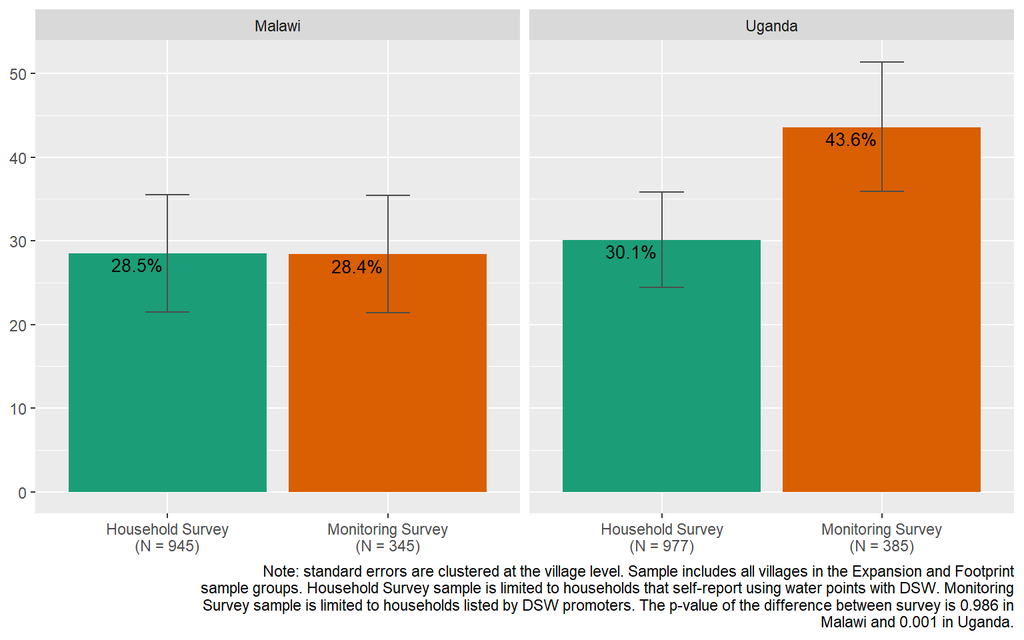

## Figure 2 - Chlorine detection rates by timing of survey

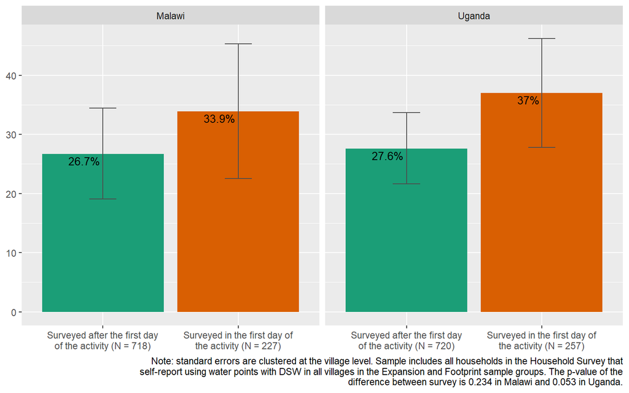

## Figure 3 - Chlorine detection rates in Household Survey by group of households

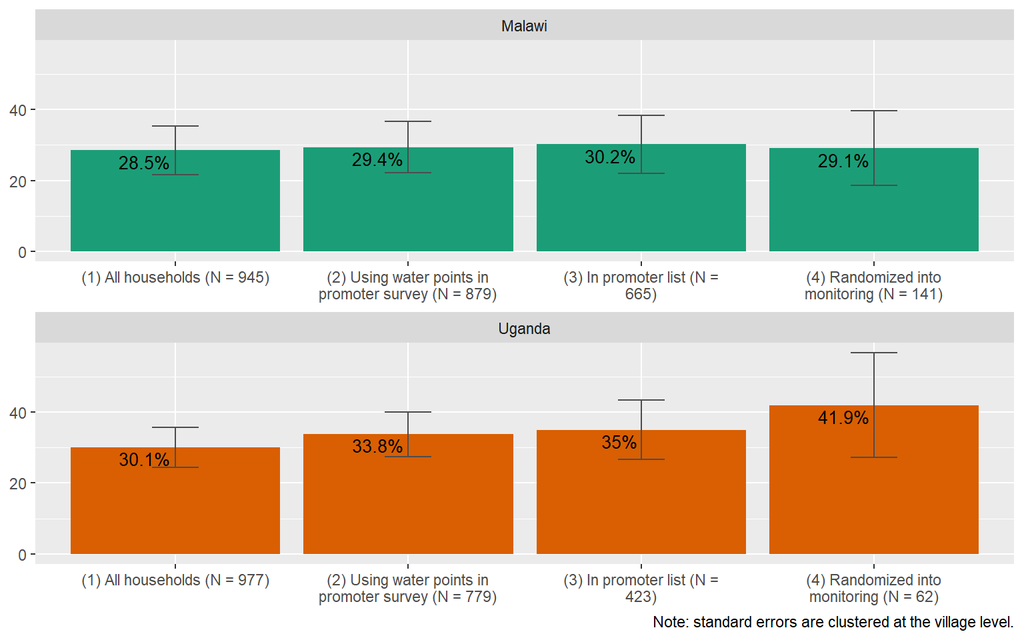

## Figure 4 - Sample selection of water points

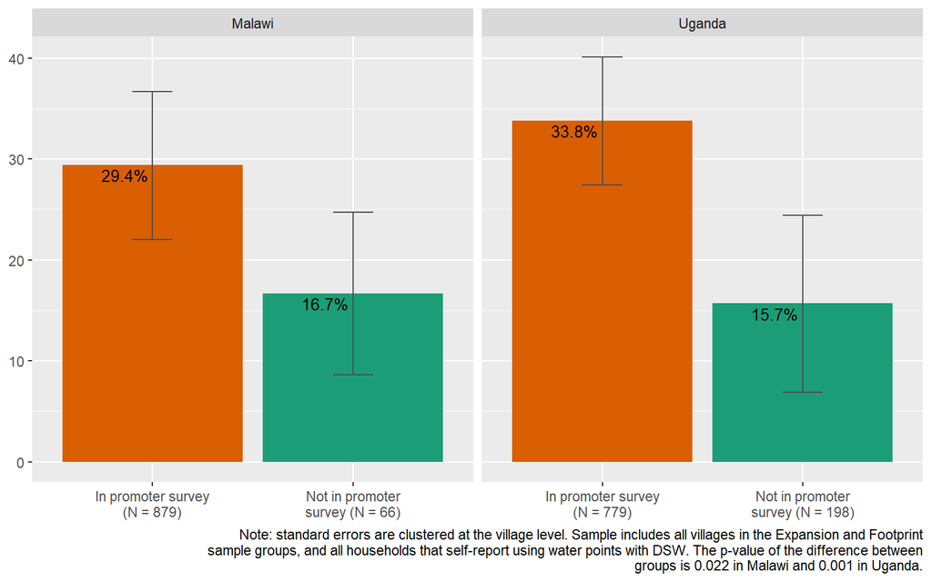

## Figure 5 - Comparison of chlorine detection rates among household using water points included in the promoter survey

[figure not shown]

## Figure 6 - Chlorine detection rates by contact with promoter {#fig:int}

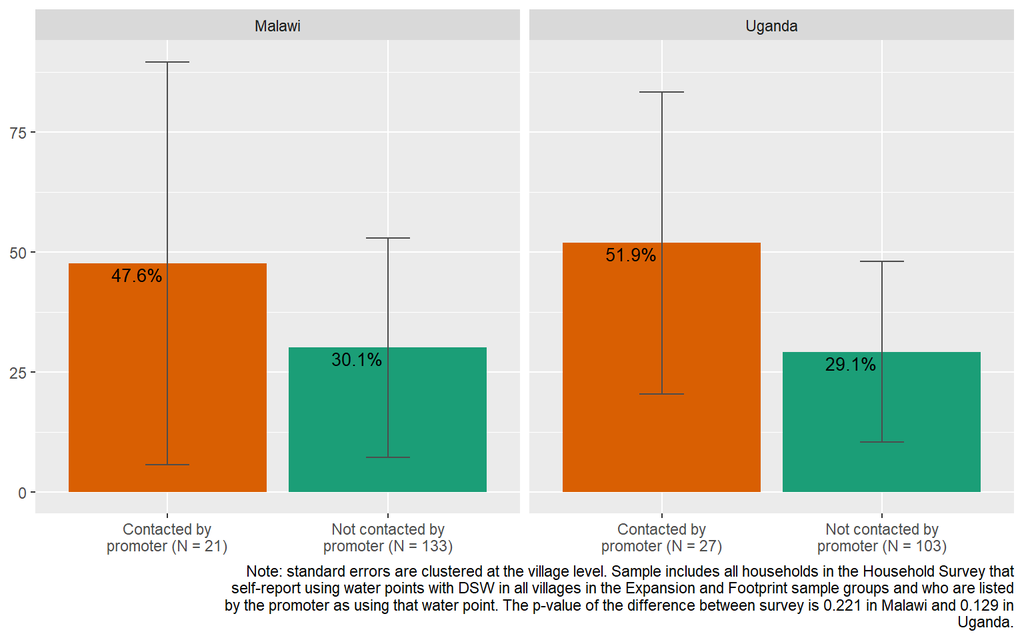

## Figure 7 - Chlorine detection rates among replaced and replacement households

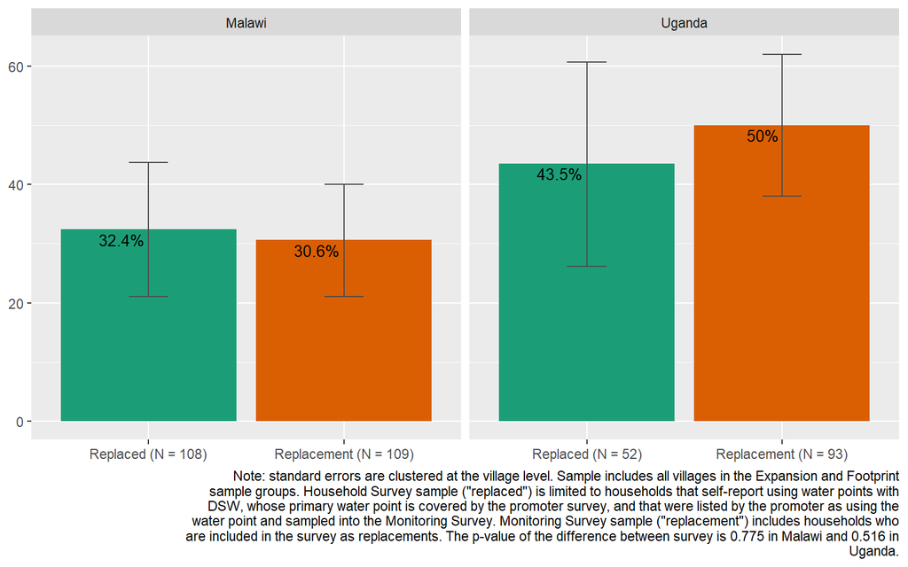

## Figure 8 - Comparision of chlorine detection rates in the Household Survey between households living inside and outside of village boundaries

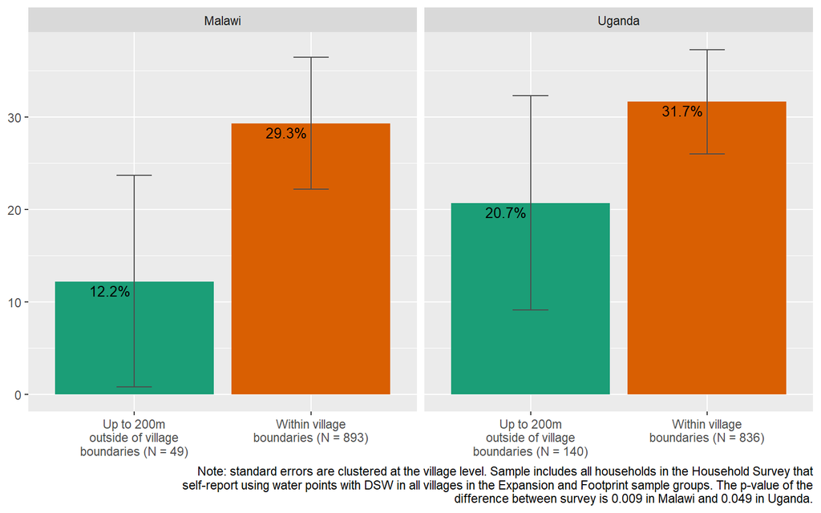

## Figure 9 - Comparision of chlorine detection rates by survey among households living within village boundaries

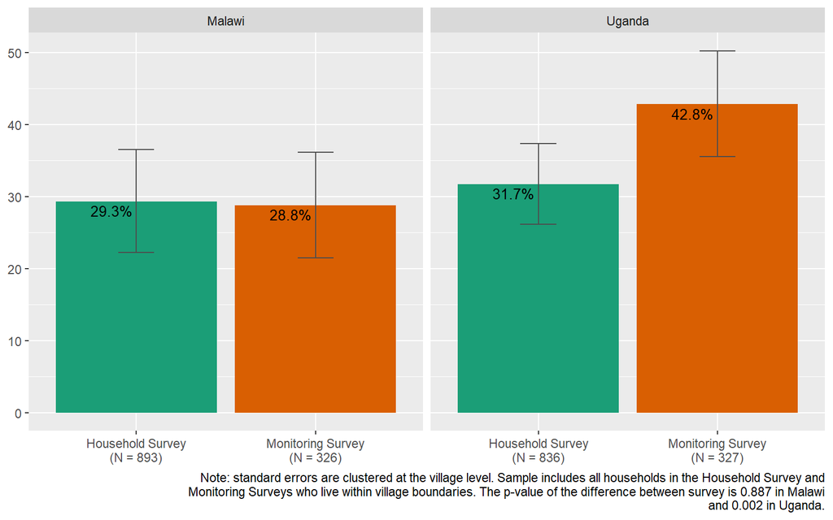